# Prosper Loan Data Exploration

## by Arshi Saleh

## Investigation Overview

My goal in this investigation is to help an investor determine the key factors to keep in mind while making investments using Prosper which is an online personal loan service based on peer-to-peer lending.

In most cases Investors are looking for higher returns which come with higher risks. At the end of the investigation I want to be able to help investors get better returns with a relatively lower risk.

## Dataset Overview

The prosper loan data set has 113937 rows and 81 columns. I will be working with 32 columns which are a mix of numeric and categorical datatypes and one column has bool datatype. There are 112935 rows in the dataset after the initial restructuring which includes melting columns CreditGrade and ProsperRating (Alpha) into one (ProspserCreditRating) as both of them provide ratings, the first for time period before 2009 and the second for time period after July, 2009. We have created CreditScore feature using the average of CreditScoreUpper & CreditScoreLower.

## Loan Status Distribution (proportion)

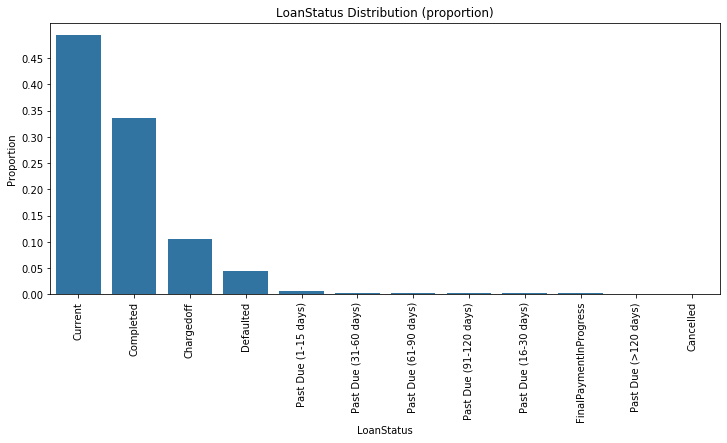

```python
# get proportion taken by most common group for derivation
# of tick marks
n_points = prosper_loan_sub.shape[0]
max_count = prosper_loan_sub['LoanStatus'].value_counts().max()
max_prop = max_count / n_points

# generate tick mark locations and names
tick_props = np.arange(0, max_prop, 0.05)
tick_names = ['{:0.2f}'.format(v) for v in tick_props]

#plot and explore the LoanStatus column
plt.figure(figsize = [12, 5])
base_color = sb.color_palette()[0]
loan_status_order = prosper_loan_sub['LoanStatus'].value_counts().index

sb.countplot(data = prosper_loan_sub, x = 'LoanStatus', color = base_color, order = loan_status_order)
plt.yticks(tick_props * n_points, tick_names)
plt.ylabel('Proportion')
plt.title('LoanStatus Distribution (proportion)')
plt.xticks(rotation = 90);
```

## Distribution of CreditScore, ProsperCreditRating, IncomeRange and LoanOriginal Amount for LoanStatus='Completed'

To have a better understanding of the borrowers that have successfully closed their loans I have explored the CreditScore, ProsperCreditRating, IncomeRange and LoanOriginalAmount for borrowers who have already closed their loans and we can see that CreditScore peaks at around 700, more number of borrowers have ProsperCreditRatings of D and C, income range between mostly lies above 25,000 dollars and loan original amount is less than 5000 in most cases.

```
''
```

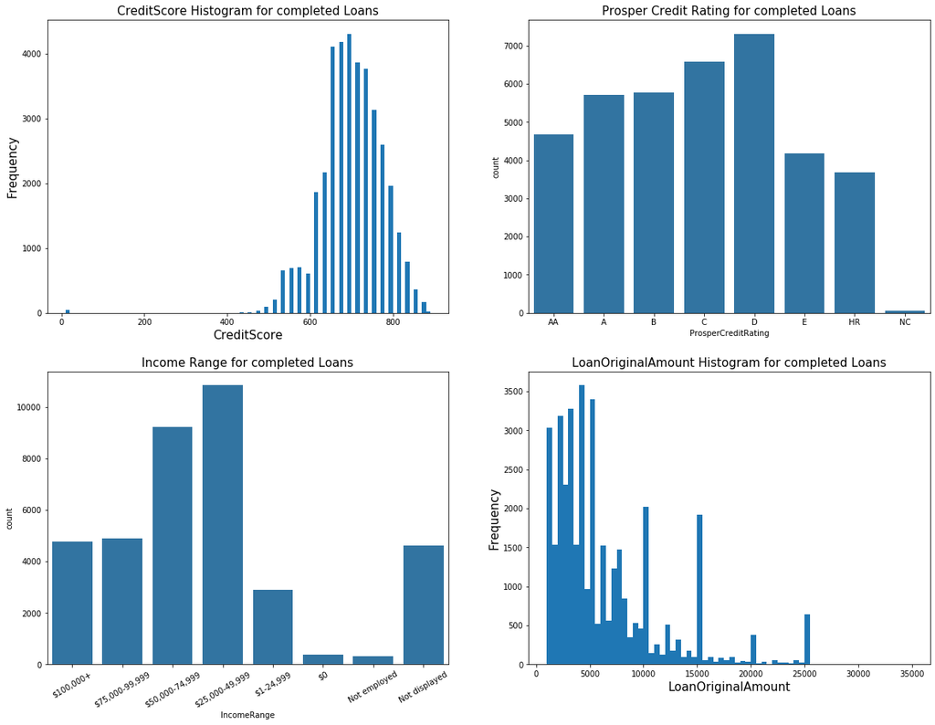

```python
#extract rows which have LoanStatus = Completed
loan_completed=prosper_loan_sub.query('LoanStatus == "Completed"')

#set figure size
plt.figure(figsize = [20,15])
default_color = sb.color_palette()[0]

#plot the creditscore for completed loans
plt.subplot(2, 2, 1) #2 row, 2 column, subplot 1
bin_edges = np.arange(loan_completed['CreditScore'].min(), loan_completed['CreditScore'].max()+10, 10)
plt.hist(data = loan_completed, x = 'CreditScore', color = default_color, bins=bin_edges)
plt.xlabel('CreditScore', fontsize=15)
plt.ylabel('Frequency', fontsize=15)
plt.title('CreditScore Histogram for completed Loans', fontsize=15)

#plot the ProsperCreditRating foe completed loans
plt.subplot(2, 2, 2) #2 row, 2 column, subplot 2
sb.countplot(data = loan_completed, x = 'ProsperCreditRating', color = default_color)
plt.title('Prosper Credit Rating for completed Loans', fontsize=15)

#plot the Income Range for the completed loans
plt.subplot(2, 2, 3) #2 row, 2 column, subplot 3
sb.countplot(data = loan_completed, x = 'IncomeRange', color = default_color)
plt.title('Income Range for completed Loans', fontsize=15)
plt.xticks(rotation=30)

#plot the LoanOriginal Amount for completed loans
plt.subplot(2, 2, 4) #2 row, 2 column, subplot 4
bin_edges = np.arange(loan_completed['LoanOriginalAmount'].min(), loan_completed['LoanOriginalAmount'].max()+100, 500)
plt.hist(data = loan_completed, x = 'LoanOriginalAmount', color = default_color, bins=bin_edges)
plt.xlabel('LoanOriginalAmount', fontsize=15)
plt.ylabel('Frequency', fontsize=15)
plt.title('LoanOriginalAmount Histogram for completed Loans', fontsize=15)
;
```

## IncomeRange v/s Average Debt To Income Ratio & Average ProsperPaymentsOneMonthPlusLate

Borrowers who are not employed have the highest debt to income ratio followed by 1-24,999 dollar income range. 75,000-99,999 and 50,000-74,999 dollars Income range borrowers have low Average Debt-to-Income ratio and smaller average ProsperPaymentsOneMonthPlusLate value. We can also observe that the error bars are longer for not employed in both plots.

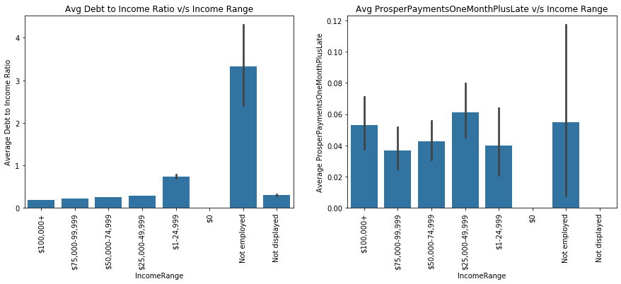

```python
#plot the IncomeRange v/s Average Debt To Income Ratio & Average ProsperPaymentsOneMonthPlusLate
#set the base color and size a barplot
plt.figure(figsize = [15, 5])
base_color = sb.color_palette()[0]
#plot Debt to Income Ratio and Income Range
#subplot 1
plt.subplot(1, 2, 1)
sb.barplot(data = prosper_loan_sub, x = 'IncomeRange', y = 'DebtToIncomeRatio', color = base_color)
plt.ylabel('Average Debt to Income Ratio')
plt.title('Avg Debt to Income Ratio v/s Income Range')
plt.xticks(rotation = 90);

#plot ProsperPaymentsOneMonthPlusLate and IncomeRange
#subplot 2
plt.subplot(1, 2, 2)
sb.barplot(data = prosper_loan_sub, x = 'IncomeRange', y = 'ProsperPaymentsOneMonthPlusLate', color = base_color)
plt.ylabel('Average ProsperPaymentsOneMonthPlusLate')
plt.title('Avg ProsperPaymentsOneMonthPlusLate v/s Income Range')
plt.xticks(rotation = 90);
```

## ProsperCreditRating v/s Estimated Return and ProsperCreditRating v/s LenderYield

We can see that Estimated Return has better returns for ProsperRatings B, C and D. HR has a higher peak than B, and C but it also has a huge number of outliers with low and negative results.

LenderYield gives us a different picture where HR has the best returns followed by E and D. Since LenderYield does not consider the estimated loss the risk factor of the HR category is not clearly visible in this plot.

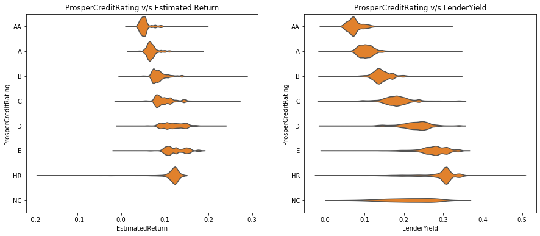

```python
#plot ProsperCreditRating v/s Estimated Return and ProsperCreditRating v/s LenderYield as subplots to compare
plt.figure(figsize = [15, 6])
base_color = sb.color_palette()[1]

#plot ProsperCreditRating v/s Estimated Return
plt.subplot(1, 2, 1)
g=sb.violinplot(data = prosper_loan_sub, x = 'EstimatedReturn', y = 'ProsperCreditRating', color = base_color,
              inner = None)
g.set_title('ProsperCreditRating v/s Estimated Return')

#plot ProsperCreditRating v/s LenderYield
plt.subplot(1, 2, 2)
g=sb.violinplot(data = prosper_loan_sub, x = 'LenderYield', y = 'ProsperCreditRating', color = base_color,
              inner = None)
g.set_title('ProsperCreditRating v/s LenderYield');
```

## LoanOriginalAmount v/s mean of Estimated Return

We can see from this plot that the estimated return is higher for smaller values of LoanOriginalAmount with peaks around 5,000$ and 7000-8000$ but the standard error of mean is more for amounts greater than 30,000 dollars.

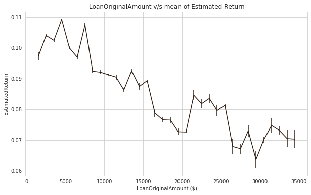

```python
#plot a line plot for LoanOriginalAmount v/s mean of Estimated Return
plt.figure(figsize = [10, 6])
# set bin edges, compute centers
bin_size = 1000
xbin_edges = np.arange(prosper_loan_sub['LoanOriginalAmount'].min(), prosper_loan_sub['LoanOriginalAmount'].max()+bin_size, bin_size)
xbin_centers = (xbin_edges + bin_size/2)[:-1]

# compute statistics in each bin
#https://www.geeksforgeeks.org/python-pandas-dataframe-sem/
data_xbins = pd.cut(prosper_loan_sub['LoanOriginalAmount'], xbin_edges, right = False, include_lowest = True)
y_means = prosper_loan_sub['EstimatedReturn'].groupby(data_xbins).mean()
y_sems = prosper_loan_sub['EstimatedReturn'].groupby(data_xbins).sem() #calculate the standard error

# plot the summarized data
with sb.color_palette("copper"): #https://seaborn.pydata.org/generated/seaborn.color_palette.html
    with sb.axes_style("whitegrid"):
        plt.errorbar(x = xbin_centers, y = y_means, yerr = y_sems)
        plt.xlabel('LoanOriginalAmount ($)')
        plt.ylabel('EstimatedReturn')
        plt.title('LoanOriginalAmount v/s mean of Estimated Return');
```

## LoanOriginalAmount v/s AmountDelinquent v/s DelinquenciesLast7Years

We can observe than borrowers with lower values of OriginalLoanAmount have more number of delinquencies in last 7 years as compared to borrowers who had high values of original loan amounts.

Similar relationship is observed between Loan OriginalAmount and AmountDelinquent, borrowers with lower values of original loan amount have higher amount delinquent as compared to borrowers with smaller value of original loan amount.

Most of the borrowers having high number of delinquencies in the last 7 years have relatively lower delinquentamounts. The probable reason can be that when lending higher amounts there is a tighter check on the financials of the borrower.

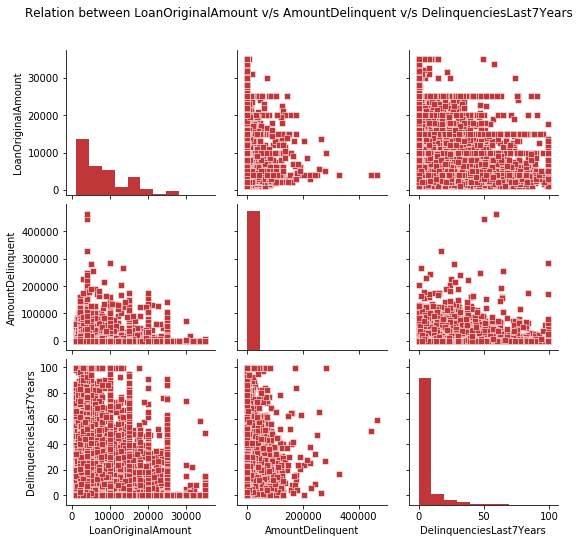

```python
# plot a pairgrid plot to explore relationship between LoanOriginalAmount, AmountDelinquent and DelinquenciesLast7Years
borrower_stats=['LoanOriginalAmount', 'AmountDelinquent','DelinquenciesLast7Years']

with sb.color_palette("RdBu"):
    g = sb.PairGrid(data = prosper_loan_sub, vars = borrower_stats,
        hue_kws={"marker": ["s"]}) #https://seaborn.pydata.org/generated/seaborn.PairGrid.html
    g.map_diag(plt.hist)
    g.map_offdiag(plt.scatter, edgecolor="w", s=40, linewidths=0.5)
    #set the title of the plot
    g.fig.suptitle('Relation between LoanOriginalAmount v/s AmountDelinquent v/s DelinquenciesLast7Years', fontsize=12)
    g.fig.subplots_adjust(top=.9); #https://stackoverflow.com/questions/28638158/seaborn-facetgrid-how-to-leave-proper-space-on-top-for-suptitle
```

## ListingCategory v/s CreditScore

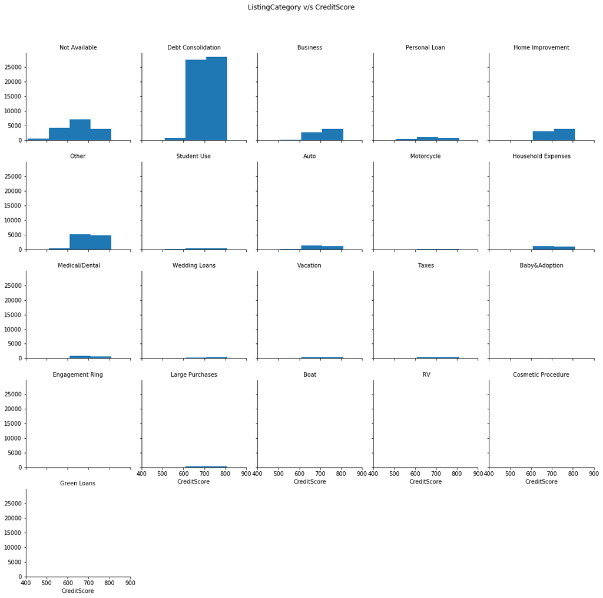

```python
#plot the Credit Score for different listing categories
#create bins
bin_edges = np.arange(prosper_loan_sub['CreditScore'].min(), prosper_loan_sub['CreditScore'].max()+10, 100)
#plot a facetgrid to observe relation between Credit Score and Listing Categories
g = sb.FacetGrid(data = prosper_loan_sub, col = 'ListingCategory', col_wrap = 5)
g.map(plt.hist, 'CreditScore', bins=bin_edges)
g.set_titles('{col_name}')
g.set(xlim=(400, 900))
g.fig.suptitle('ListingCategory v/s CreditScore', fontsize=12)
g.fig.subplots_adjust(top=.9);
```

## LoanStatus v/s Occupation v/s Estimated Return

I have included other in this chart which was previously excluded in the univariant exploration because there are a huge number of borrowers who do not disclose their occupation. In this plot we can observe that professional and other have similar boxplots in all cases except FinalPayment in progress. This reflects that professional is also a generalised category like Other.

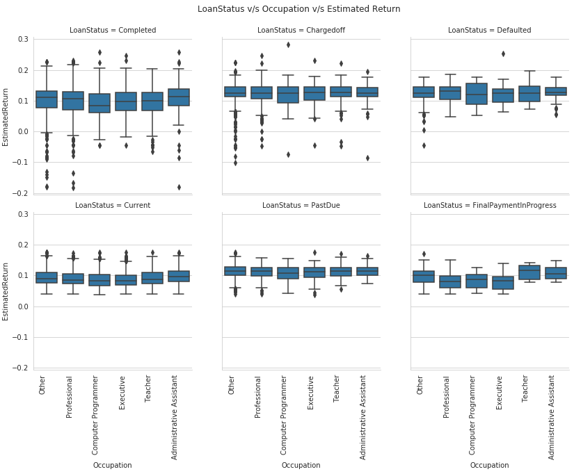

```python
#group all the different PastDue LoanStatus into single category PastDue
prosper_loan_sub["LoanStatus"].replace({"Past Due (1-15 days)": "PastDue", "Past Due (31-60 days)": "PastDue",
                          "Past Due (61-90 days)": "PastDue", "Past Due (91-120 days)": "PastDue",
                        "Past Due (16-30 days)": "PastDue", "Past Due (>120 days)": "PastDue"}, inplace=True)

#exclude "Cancelled" from the LoanStatus
loan_df=prosper_loan_sub[prosper_loan_sub['LoanStatus'].isin(["Current","Completed","Chargedoff","Defaulted","PastDue","FinalPaymentInProgress"])]
#set the order for occupation and we will limit this variable to the top five most frequent occupations
occupation_order=prosper_loan_sub['Occupation'].value_counts().head(6).index

#facet bivariate plots to create a multivariate visualization
#plot boxplot for LoanStatus v/s Occupation v/s Estimated Return
with sb.axes_style("whitegrid"):
    g = sb.FacetGrid(data = loan_df, col = 'LoanStatus', height = 4, col_wrap = 3)
    g.map(sb.boxplot, 'Occupation', 'EstimatedReturn',order=occupation_order)
    g.fig.suptitle('LoanStatus v/s Occupation v/s Estimated Return', fontsize=12)
    g.fig.subplots_adjust(top=.9)

#https://www.drawingfromdata.com/how-to-rotate-axis-labels-in-seaborn-and-matplotlib
for axes in g.axes.flat:
    axes.set_xticklabels(axes.get_xticklabels(), rotation=90, horizontalalignment='right');
```

## Explore Relation between IncomeRange, ProsperCreditRating ProsperPaymentsOneMonthPlusLate, ProsperPaymentsLessThanOneMonthLateLoanOriginalAmount and InquiriesLast6Months

We can observe that income range 50,000-74,999 and 25,000-49,999 dollars and ProsperCreditRating D and E have the most number of outliers in relation to ProsperPaymentsOneMonthPlusLate.

The InquiriesLast6Months has maximum outliers for ProsperCreditRating HR and IncomeRange Not Displayed followed by 50,000-74,999 dollars

ProsperPaymentsLessThanOneMonthLate has maximum outliers for ProsperCreditRating AA followed by HR and D and for IncomeRange 50,000-74,999 , 75,000-99,999 and 1,00,000+ dollars.

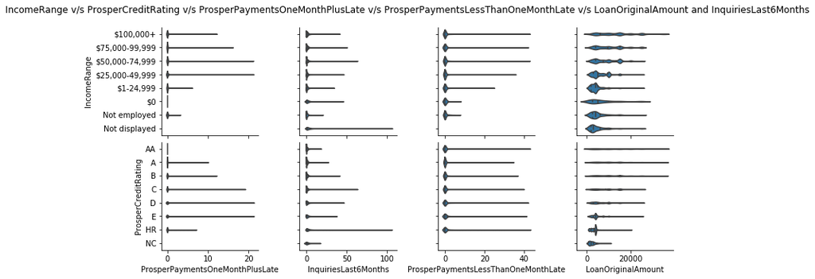

```python
#explore relationship between numerical & categorical variables using pairgrid
#plot a violin plot to understand the relationship between IncomeRange, ProsperCreditRating ProsperPaymentsOneMonthPlusLate, ProsperPaymentsLessThanOneMonthLate
#LoanOriginalAmount and InquiriesLast6Months
#https://seaborn.pydata.org/generated/seaborn.PairGrid.html

g = sb.PairGrid(data = prosper_loan_sub, x_vars = ['ProsperPaymentsOneMonthPlusLate', 'InquiriesLast6Months',
                                                   'ProsperPaymentsLessThanOneMonthLate', 'LoanOriginalAmount'],
                y_vars = ['IncomeRange','ProsperCreditRating'])
g.map(sb.violinplot, inner = 'quartile')
g.fig.suptitle('IncomeRange v/s ProsperCreditRating v/s ProsperPaymentsOneMonthPlusLate v/s ProsperPaymentsLessThanOneMonthLate v/s LoanOriginalAmount and InquiriesLast6Months',
              fontsize=12)
g.fig.subplots_adjust(top=.9);
```